# Distribution Grid Search

This is the example vignette for function: [snw_ds_main_grid_search](https://github.com/FanWangEcon/PrjOptiSNW/blob/master/PrjOptiSNW/sdist/snw_ds_main_grid_search.m) from the [PrjOptiSNW Package](https://fanwangecon.github.io/PrjOptiSNW/). This function solves for vfi and gets distribution induced by policy functions and exogenous distributions. Grid Search for VFI and Grid Search also for Distribution. The results are illustrative of the differences between using grid search and exact solution. The grid search solution here is not fully vectorized but loops over the state-space.

## Test SNW_DS_MAIN_GRID_SEARCH Defaults More Dense

Rather than solving for "docdense", this solves for "moredense", which has fewer shocks, in order to save time given the relatively slow speed of this algorithm.

```matlab
mp_params = snw_mp_param('default_moredense');
mp_controls = snw_mp_control('default_test');
mp_controls('bl_print_vfi') = false;
mp_controls('bl_print_ds') = false;
mp_controls('bl_print_ds_verbose') = false;
[Phi_true,Phi_adj,A_agg,Y_inc_agg,it,mp_dsvfi_results] = snw_ds_main_grid_search(mp_params, mp_controls);
```

Elapsed time is 13045.688258 seconds. Completed SNW_VFI_MAIN_GRID_SEARCH;SNW_MP_PARAM=default_moredense;SNW_MP_CONTROL=default_test Elapsed time is 13841.078692 seconds. Completed SNW_DS_MAIN;SNW_MP_PARAM=;default_moredense;SNW_MP_CONTROL=;default_test

```matlab
Phi_true = Phi_true/sum(Phi_true(:));
```

## Show All Info in mp_dsvfi_results More Dense

```matlab
mp_cl_mt_xyz_of_s = mp_dsvfi_results('mp_cl_mt_xyz_of_s');
disp(mp_cl_mt_xyz_of_s('tb_outcomes'))
```

**mean** **unweighted_sum** **sd** **coefofvar** **gini** **min** **max** **pYis0** **pYls0** **pYgr0** **pYisMINY** **pYisMAXY** **p0_01** **p0_1** **p1** **p5** **p10** **p20** **p25** **p30** **p40** **p50** **p60** **p70** **p75** **p80** **p90** **p95** **p99** **p99_9** **p99_99** **fl_cov_a_ss** **fl_cor_a_ss** **fl_cov_ap_ss** **fl_cor_ap_ss** **fl_cov_cons_ss** **fl_cor_cons_ss** **fl_cov_v_ss** **fl_cor_v_ss** **fl_cov_n_ss** **fl_cor_n_ss** **fl_cov_y_all** **fl_cor_y_all** **fl_cov_y_head_inc** **fl_cor_y_head_inc** **fl_cov_y_head_earn** **fl_cor_y_head_earn** **fl_cov_y_spouse_inc** **fl_cor_y_spouse_inc** **fl_cov_yshr_interest** **fl_cor_yshr_interest** **fl_cov_yshr_wage** **fl_cor_yshr_wage** **fl_cov_yshr_SS** **fl_cor_yshr_SS** **fl_cov_yshr_tax** **fl_cor_yshr_tax** **fl_cov_yshr_nttxss** **fl_cor_yshr_nttxss** **fracByP0_01** **fracByP0_1** **fracByP1** **fracByP5** **fracByP10** **fracByP20** **fracByP25** **fracByP30** **fracByP40** **fracByP50** **fracByP60** **fracByP70** **fracByP75** **fracByP80** **fracByP90** **fracByP95** **fracByP99** **fracByP99_9** **fracByP99_99** **________** **______________** **________** **_________** **_______** **________** **_______** **_______** **_______** **_______** **__________** **__________** **________** **________** **________** **________** **________** **__________** **_________** **_________** **________** **________** **________** **_______** **________** **________** **_______** **_______** **_______** **_______** **_______** **___________** **___________** **____________** **____________** **______________** **______________** **___________** **___________** **___________** **___________** **____________** **____________** **_________________** **_________________** **__________________** **__________________** **___________________** **___________________** **____________________** **____________________** **________________** **________________** **______________** **______________** **_______________** **_______________** **__________________** **__________________** **___________** **__________** **__________** **_________** **_________** **__________** **__________** **__________** **_________** **_________** **_________** **_________** **_________** **__________** **_________** **_________** **_________** **___________** **____________** **a_ss** 4.2955 5130.2 8.2965 1.9314 0.74079 0 135 0.17669 0 0.82331 0.17669 1.677e-05 0 0 0 0 0 0.005 0.02916 0.08788 0.48668 1.08 2.0261 3.8934 5 6.655 12.031 18.982 38.812 83.886 124.49 68.832 1 169.22 0.79723 5.4878 0.64966 90.469 0.30584 -1.6403 -0.13754 7.6543 0.48605 6.9504 0.54255 4.0118 0.33952 0.70393 0.088346 0.91831 0.62603 -0.89966 -0.3189 -0.018657 -0.0094705 0.12551 0.3732 0.14417 0.067175 0 0 0 0 0 1.5597e-05 0.00022606 0.00089584 0.0081262 0.026878 0.060803 0.13621 0.1847 0.25364 0.46061 0.6383 0.8679 0.97776 0.99771 **ap_ss** 33.948 11476 25.584 0.75362 0.43382 1 151 0 0 1 0.15798 1.7142e-05 1 1 1 1 1 8 12 16 25 32 3…

## More Dense Param Results Define Frames

Define the matrix dimensions names and dimension vector values. Probability mass matrixes, Policy and Value Functions share the same ND dimensional structure.

```matlab
% Grids:
age_grid = 18:100;
agrid = mp_params('agrid')';
eta_H_grid = mp_params('eta_H_grid')';
eta_S_grid = mp_params('eta_S_grid')';
ar_st_eta_HS_grid = string(cellstr([num2str(eta_H_grid', 'hz=%3.2f;'), num2str(eta_S_grid', 'wz=%3.2f')]));
edu_grid = [0,1];
marry_grid = [0,1];
kids_grid = (1:1:mp_params('n_kidsgrid'))';
% NaN(n_jgrid,n_agrid,n_etagrid,n_educgrid,n_marriedgrid,n_kidsgrid);
cl_mp_datasetdesc = {};
cl_mp_datasetdesc{1} = containers.Map({'name', 'labval'}, {'age', age_grid});
cl_mp_datasetdesc{2} = containers.Map({'name', 'labval'}, {'savings', agrid});
cl_mp_datasetdesc{3} = containers.Map({'name', 'labval'}, {'eta', 1:length(eta_H_grid)});
cl_mp_datasetdesc{4} = containers.Map({'name', 'labval'}, {'edu', edu_grid});
cl_mp_datasetdesc{5} = containers.Map({'name', 'labval'}, {'marry', marry_grid});
cl_mp_datasetdesc{6} = containers.Map({'name', 'labval'}, {'kids', kids_grid});
```

## Analyze Probability Mass Along Age Dimensions

Where are the mass at? Analyze mass given state space components.

```matlab
% Get the Joint distribution over all states
% Define Graph Inputs
mp_support_graph = containers.Map('KeyType', 'char', 'ValueType', 'any');
mp_support_graph('st_legend_loc') = 'best';
mp_support_graph('bl_graph_logy') = false; % do not log
```

Exogenous Permanent States Mass: Life Cycle, Edu and Marraige

Tabulate value and policies along savings and shocks:

```matlab
% NaN(n_jgrid,n_agrid,n_etagrid,n_educgrid,n_marriedgrid,n_kidsgrid);
ar_permute = [2,3,6,1,5,4];
% Value Function
tb_prob_aem = ff_summ_nd_array("P(Age, EDU, MARRY))", Phi_true, true, ["sum"], 3, 1, cl_mp_datasetdesc, ar_permute);
```

xxx P(Age, EDU, MARRY)) xxxxxxxxxxxxxxxxxxxxxxxxxxx **group** **marry** **edu** **sum_age_18** **sum_age_19** **sum_age_20** **sum_age_21** **sum_age_22** **sum_age_23** **sum_age_24** **sum_age_25** **sum_age_26** **sum_age_27** **sum_age_28** **sum_age_29** **sum_age_30** **sum_age_31** **sum_age_32** **sum_age_33** **sum_age_34** **sum_age_35** **sum_age_36** **sum_age_37** **sum_age_38** **sum_age_39** **sum_age_40** **sum_age_41** **sum_age_42** **sum_age_43** **sum_age_44** **sum_age_45** **sum_age_46** **sum_age_47** **sum_age_48** **sum_age_49** **sum_age_50** **sum_age_51** **sum_age_52** **sum_age_53** **sum_age_54** **sum_age_55** **sum_age_56** **sum_age_57** **sum_age_58** **sum_age_59** **sum_age_60** **sum_age_61** **sum_age_62** **sum_age_63** **sum_age_64** **sum_age_65** **sum_age_66** **sum_age_67** **sum_age_68** **sum_age_69** **sum_age_70** **sum_age_71** **sum_age_72** **sum_age_73** **sum_age_74** **sum_age_75** **sum_age_76** **sum_age_77** **sum_age_78** **sum_age_79** **sum_age_80** **sum_age_81** **sum_age_82** **sum_age_83** **sum_age_84** **sum_age_85** **sum_age_86** **sum_age_87** **sum_age_88** **sum_age_89** **sum_age_90** **sum_age_91** **sum_age_92** **sum_age_93** **sum_age_94** **sum_age_95** **sum_age_96** **sum_age_97** **sum_age_98** **sum_age_99** **sum_age_100** **_____** **_____** **___** **__________** **__________** **__________** **__________** **__________** **__________** **__________** **__________** **__________** **__________** **__________** **__________** **__________** **__________** **__________** **__________** **__________** **__________** **__________** **__________** **__________** **__________** **__________** **__________** **__________** **__________** **__________** **__________** **__________** **__________** **__________** **__________** **__________** **__________** **__________** **__________** **__________** **__________** **__________** **__________** **__________** **__________** **__________** **__________** **__________** **__________** **__________** **__________** **__________** **__________** **__________** **__________** **__________** **__________** **__________** **__________** **__________** **__________** **__________** **__________** **__________** **__________** **__________** **__________** **__________** **__________** **__________** **__________** **__________** **__________** **__________** **__________** **__________** **__________** **__________** **__________** **__________** **__________** **__________** **__________** **__________** **__________** **___________** 1 0 0 0.0085768 0.0084866 0.0083969 0.0083078 0.0082194 0.0081317 0.008045 0.0079593 0.0078747 0.0077911 0.0077085 0.0076266 0.0075453 0.0074646 0.0073844 0.0073046 0.0072252 0.0071459 0.0070668 0.0069879 0.0069091 0.0068303 0.0067514 0.0066726 0.0065937 0.0065147 0.0064357 0.0063567 0.0062776 0.0061983 0.0061189 0.0060396 0.0059603 0.005881 0.0058016 0.0057216 0.0056408 0.0055589 0.0054756 0.0053…

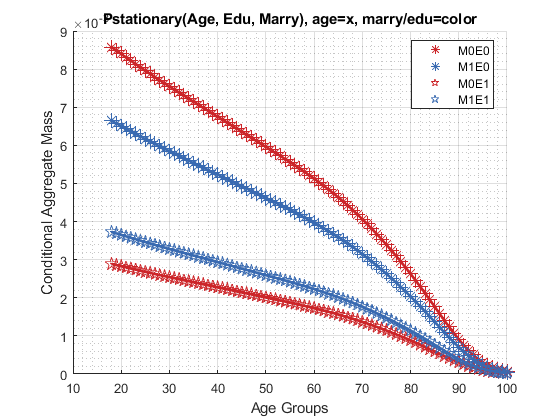

```matlab
mp_support_graph('cl_st_graph_title') = {'Pstationary(Age, Edu, Marry), age=x, marry/edu=color'};
mp_support_graph('cl_st_ytitle') = {'Conditional Aggregate Mass'};
ar_row_grid = ["M0E0", "M1E0", "M0E1", "M1E1"];
mp_support_graph('cl_st_xtitle') = {'Age Groups'};
mp_support_graph('cl_scatter_shapes') = {'*', '*', 'p', 'p' };
mp_support_graph('cl_colors') = {'red', 'blue', 'red', 'blue'};
ff_graph_grid((tb_prob_aem{1:end, 4:end}), ar_row_grid, age_grid, mp_support_graph);
```

Kids and Marry By Age Mass

```matlab
% NaN(n_jgrid,n_agrid,n_etagrid,n_educgrid,n_marriedgrid,n_kidsgrid);
ar_permute = [2,3,4,1,6,5];
% Value Function
tb_prob_amarrykids = ff_summ_nd_array("P(Age, Kids, Marry))", Phi_true, true, ["sum"], 3, 1, cl_mp_datasetdesc, ar_permute);
```

xxx P(Age, Kids, Marry)) xxxxxxxxxxxxxxxxxxxxxxxxxxx **group** **kids** **marry** **sum_age_18** **sum_age_19** **sum_age_20** **sum_age_21** **sum_age_22** **sum_age_23** **sum_age_24** **sum_age_25** **sum_age_26** **sum_age_27** **sum_age_28** **sum_age_29** **sum_age_30** **sum_age_31** **sum_age_32** **sum_age_33** **sum_age_34** **sum_age_35** **sum_age_36** **sum_age_37** **sum_age_38** **sum_age_39** **sum_age_40** **sum_age_41** **sum_age_42** **sum_age_43** **sum_age_44** **sum_age_45** **sum_age_46** **sum_age_47** **sum_age_48** **sum_age_49** **sum_age_50** **sum_age_51** **sum_age_52** **sum_age_53** **sum_age_54** **sum_age_55** **sum_age_56** **sum_age_57** **sum_age_58** **sum_age_59** **sum_age_60** **sum_age_61** **sum_age_62** **sum_age_63** **sum_age_64** **sum_age_65** **sum_age_66** **sum_age_67** **sum_age_68** **sum_age_69** **sum_age_70** **sum_age_71** **sum_age_72** **sum_age_73** **sum_age_74** **sum_age_75** **sum_age_76** **sum_age_77** **sum_age_78** **sum_age_79** **sum_age_80** **sum_age_81** **sum_age_82** **sum_age_83** **sum_age_84** **sum_age_85** **sum_age_86** **sum_age_87** **sum_age_88** **sum_age_89** **sum_age_90** **sum_age_91** **sum_age_92** **sum_age_93** **sum_age_94** **sum_age_95** **sum_age_96** **sum_age_97** **sum_age_98** **sum_age_99** **sum_age_100** **_____** **____** **_____** **__________** **__________** **__________** **__________** **__________** **__________** **__________** **__________** **__________** **__________** **__________** **__________** **__________** **__________** **__________** **__________** **__________** **__________** **__________** **__________** **__________** **__________** **__________** **__________** **__________** **__________** **__________** **__________** **__________** **__________** **__________** **__________** **__________** **__________** **__________** **__________** **__________** **__________** **__________** **__________** **__________** **__________** **__________** **__________** **__________** **__________** **__________** **__________** **__________** **__________** **__________** **__________** **__________** **__________** **__________** **__________** **__________** **__________** **__________** **__________** **__________** **__________** **__________** **__________** **__________** **__________** **__________** **__________** **__________** **__________** **__________** **__________** **__________** **__________** **__________** **__________** **__________** **__________** **__________** **__________** **__________** **__________** **___________** 1 1 0 0.0091249 0.0080278 0.0071652 0.0064765 0.0059205 0.0054683 0.0050992 0.0047982 0.0045538 0.0043571 0.0042017 0.0040823 0.0039948 0.0039361 0.0039038 0.003896 0.0039111 0.0039475 0.0040043 0.0040801 0.0041738 0.0042841 0.0044094 0.0045482 0.0046984 0.0048579 0.005024 0.005194 0.0053649 0.0055336 0.0056969 0.005852 0.0059958 0.0061259 0.0062398 0.0063356 0.0064118 0.0064673 0.006502 0.0065…

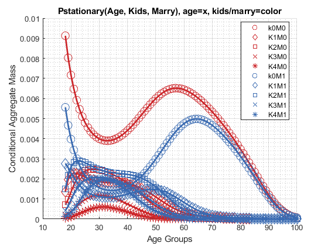

```matlab
mp_support_graph('cl_st_graph_title') = {'Pstationary(Age, Kids, Marry), age=x, kids/marry=color'};
mp_support_graph('cl_st_ytitle') = {'Conditional Aggregate Mass'};
ar_row_grid = [...
    "k0M0", "K1M0", "K2M0", "K3M0", "K4M0", ...
    "k0M1", "K1M1", "K2M1", "K3M1", "K4M1"];
mp_support_graph('cl_scatter_shapes') = {...
    'o', 'd' ,'s', 'x', '*', ...
    'o', 'd', 's', 'x', '*'};
mp_support_graph('cl_colors') = {...
    'red', 'red', 'red', 'red', 'red'...
    'blue', 'blue', 'blue', 'blue', 'blue'};
mp_support_graph('cl_st_xtitle') = {'Age Groups'};
ff_graph_grid((tb_prob_amarrykids{1:end, 4:end}), ar_row_grid, age_grid, mp_support_graph);
```

## Analyze Probability Mass Asset and Shock Dimensions

Where are the mass at?

```matlab
% Define Graph Inputs
mp_support_graph = containers.Map('KeyType', 'char', 'ValueType', 'any');
mp_support_graph('st_legend_loc') = 'best';
mp_support_graph('bl_graph_logy') = false; % do not log
```

Asset and Shock Mass

```matlab
% NaN(n_jgrid,n_agrid,n_etagrid,n_educgrid,n_marriedgrid,n_kidsgrid);
ar_permute = [1,4,5,6,3,2];
% Value Function
tb_prob_az = ff_summ_nd_array("P(A,Z))", Phi_true, true, ["sum"], 4, 1, cl_mp_datasetdesc, ar_permute);
```

xxx P(A,Z)) xxxxxxxxxxxxxxxxxxxxxxxxxxx **group** **savings** **sum_eta_1** **sum_eta_2** **sum_eta_3** **sum_eta_4** **sum_eta_5** **sum_eta_6** **sum_eta_7** **sum_eta_8** **sum_eta_9** **sum_eta_10** **sum_eta_11** **sum_eta_12** **sum_eta_13** **sum_eta_14** **sum_eta_15** **sum_eta_16** **sum_eta_17** **sum_eta_18** **sum_eta_19** **sum_eta_20** **sum_eta_21** **sum_eta_22** **sum_eta_23** **sum_eta_24** **sum_eta_25** **sum_eta_26** **sum_eta_27** **sum_eta_28** **sum_eta_29** **sum_eta_30** **sum_eta_31** **sum_eta_32** **sum_eta_33** **sum_eta_34** **sum_eta_35** **sum_eta_36** **sum_eta_37** **sum_eta_38** **sum_eta_39** **sum_eta_40** **sum_eta_41** **sum_eta_42** **sum_eta_43** **sum_eta_44** **sum_eta_45** **_____** **_______** **__________** **__________** **__________** **__________** **__________** **__________** **__________** **__________** **__________** **__________** **__________** **__________** **__________** **__________** **__________** **__________** **__________** **__________** **__________** **__________** **__________** **__________** **__________** **__________** **__________** **__________** **__________** **__________** **__________** **__________** **__________** **__________** **__________** **__________** **__________** **__________** **__________** **__________** **__________** **__________** **__________** **__________** **__________** **__________** **__________** 1 0 1.7754e-05 0.00011362 0.00037708 0.00061913 0.00056244 0.00033244 0.00011597 1.9823e-05 1.6988e-06 0.00031138 0.0019928 0.0066135 0.010859 0.0098645 0.0058306 0.002034 0.00034768 2.9794e-05 0.00079406 0.0050817 0.016865 0.027691 0.025155 0.014869 0.0051868 0.00088661 7.5978e-05 0.00031138 0.0019928 0.0066135 0.010859 0.0098645 0.0058306 0.002034 0.00034768 2.9794e-05 1.7754e-05 0.00011362 0.00037708 0.00061913 0.00056244 0.00033244 0.00011597 1.9823e-05 1.6988e-06 2 4e-05 2.8763e-07 1.3442e-06 4.0195e-06 3.6795e-07 6.5205e-06 1.2822e-06 2.0438e-08 3.2978e-09 8.1009e-12 5.0447e-06 2.3576e-05 7.0498e-05 6.4534e-06 0.00011436 2.2487e-05 3.5845e-07 5.784e-08 1.4208e-10 1.2864e-05 6.0121e-05 0.00017978 1.6457e-05 0.00029163 5.7345e-05 9.1409e-07 1.475e-07 3.6232e-10 5.0447e-06 2.3576e-05 7.0498e-05 6.4534e-06 0.00011436 2.2487e-05 3.5845e-07 5.784e-08 1.4208e-10 2.8763e-07 1.3442e-06 4.0195e-06 3.6795e-07 6.5205e-06 1.2822e-06 2.0438e-08 3.2978e-09 8.1009e-12 3 0.00032 8.5896e-07 2.1837e-06 1.5288e-05 9.7352e-06 3.0233e-05 2.2281e-06 7.9033e-08 1.9277e-08 9.9394e-11 1.5065e-05 3.8299e-05 0.00026813 0.00017074 0.00053026 3.9077e-05 1.3861e-06 3.381e-07 1.7433e-09 3.8418e-05 9.7666e-05 0.00068375 0.00043541 0.0013522 9.9651e-05 3.5348e-06 8.6219e-07 4.4454e-09 1.5065e-05 3.8299e-05 0.00026813 0.00017074 0.00053026 3.9077e-05 1.3861e-06 3.381e-07 1.7433e-09 8.5896e-07 2.1837e-06 1.5288e-05 9.7352e-06 3.0233e-05 2.2281e-06 7.9033e-08 1.9277e-08 9.9394e-11 4 0.00108 2.4168e-06 6.6439e-06 8.5514e-06 8.806e-06 1.0167e-05 3.836e-06 3.4378e-07 1.7679e-07 9.38…

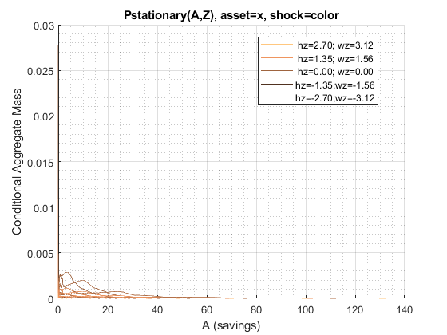

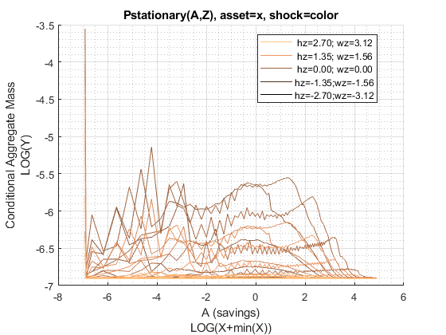

```matlab
mp_support_graph('cl_st_graph_title') = {'Pstationary(A,Z), asset=x, shock=color'};
mp_support_graph('cl_st_ytitle') = {'Conditional Aggregate Mass'};
mp_support_graph('cl_st_xtitle') = {'A (savings)'};
mp_support_graph('st_rowvar_name') = 'z=';
mp_support_graph('it_legend_select') = 5;
mp_support_graph('st_rounding') = '6.2f';
mp_support_graph('bl_graph_logy') = true;
mp_support_graph('cl_colors') = 'copper';
ff_graph_grid((tb_prob_az{1:end, 3:end})', ar_st_eta_HS_grid, agrid, mp_support_graph);% Consumption Choices
```

Asset Mass by Age

```matlab
% NaN(n_jgrid,n_agrid,n_etagrid,n_educgrid,n_marriedgrid,n_kidsgrid);
ar_permute = [3,4,5,6,1,2];
% Value Function
tb_prob_aage = ff_summ_nd_array("P(A,Z))", Phi_true, true, ["sum"], 4, 1, cl_mp_datasetdesc, ar_permute);
```

xxx P(A,Z)) xxxxxxxxxxxxxxxxxxxxxxxxxxx **group** **savings** **sum_age_18** **sum_age_19** **sum_age_20** **sum_age_21** **sum_age_22** **sum_age_23** **sum_age_24** **sum_age_25** **sum_age_26** **sum_age_27** **sum_age_28** **sum_age_29** **sum_age_30** **sum_age_31** **sum_age_32** **sum_age_33** **sum_age_34** **sum_age_35** **sum_age_36** **sum_age_37** **sum_age_38** **sum_age_39** **sum_age_40** **sum_age_41** **sum_age_42** **sum_age_43** **sum_age_44** **sum_age_45** **sum_age_46** **sum_age_47** **sum_age_48** **sum_age_49** **sum_age_50** **sum_age_51** **sum_age_52** **sum_age_53** **sum_age_54** **sum_age_55** **sum_age_56** **sum_age_57** **sum_age_58** **sum_age_59** **sum_age_60** **sum_age_61** **sum_age_62** **sum_age_63** **sum_age_64** **sum_age_65** **sum_age_66** **sum_age_67** **sum_age_68** **sum_age_69** **sum_age_70** **sum_age_71** **sum_age_72** **sum_age_73** **sum_age_74** **sum_age_75** **sum_age_76** **sum_age_77** **sum_age_78** **sum_age_79** **sum_age_80** **sum_age_81** **sum_age_82** **sum_age_83** **sum_age_84** **sum_age_85** **sum_age_86** **sum_age_87** **sum_age_88** **sum_age_89** **sum_age_90** **sum_age_91** **sum_age_92** **sum_age_93** **sum_age_94** **sum_age_95** **sum_age_96** **sum_age_97** **sum_age_98** **sum_age_99** **sum_age_100** **_____** **_______** **__________** **__________** **__________** **__________** **__________** **__________** **__________** **__________** **__________** **__________** **__________** **__________** **__________** **__________** **__________** **__________** **__________** **__________** **__________** **__________** **__________** **__________** **__________** **__________** **__________** **__________** **__________** **__________** **__________** **__________** **__________** **__________** **__________** **__________** **__________** **__________** **__________** **__________** **__________** **__________** **__________** **__________** **__________** **__________** **__________** **__________** **__________** **__________** **__________** **__________** **__________** **__________** **__________** **__________** **__________** **__________** **__________** **__________** **__________** **__________** **__________** **__________** **__________** **__________** **__________** **__________** **__________** **__________** **__________** **__________** **__________** **__________** **__________** **__________** **__________** **__________** **__________** **__________** **__________** **__________** **__________** **__________** **___________** 1 0 0.021837 0.002388 0.0018389 0.0064409 0.0087881 0.010534 0.010485 0.0093089 0.0090425 0.008346 0.0081864 0.0075468 0.0072506 0.0063016 0.0057565 0.0048062 0.0045938 0.0043442 0.0037411 0.0034783 0.0032043 0.0023008 0.0021265 0.0019691 0.0016888 0.0014765 0.0012985 0.00092769 0.0008317 0.00072292 0.00063377 0.0005339 0.0003748 0.00031779 0.00027146 0.00021668 0.00016989 0.00013889 0.00011638 9.5265e-05 7.661e-05 6.238…

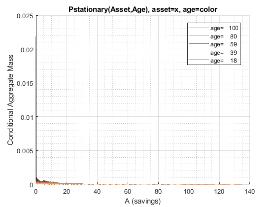

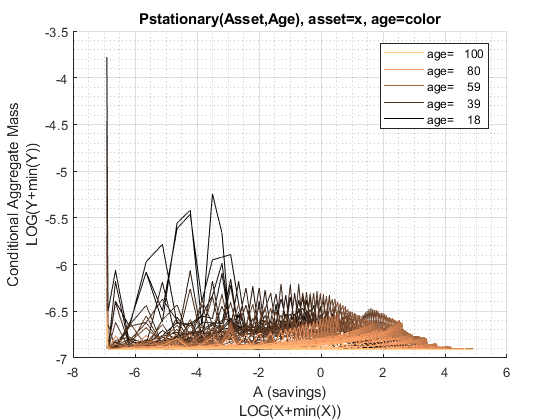

```matlab
mp_support_graph('cl_st_graph_title') = {'Pstationary(Asset,Age), asset=x, age=color'};
mp_support_graph('cl_st_ytitle') = {'Conditional Aggregate Mass'};
mp_support_graph('cl_st_xtitle') = {'A (savings)'};
mp_support_graph('st_rowvar_name') = 'age=';
mp_support_graph('it_legend_select') = 5;
mp_support_graph('st_rounding') = '6.0f';
mp_support_graph('bl_graph_logy') = true;
mp_support_graph('cl_colors') = 'copper';
ff_graph_grid((tb_prob_aage{1:end, 3:end})', age_grid, agrid, mp_support_graph);% Consumption Choices
```

## Probability Statistics A, C and V Conditional on Ages

Where are the mass at?

```matlab
ap_ss = mp_dsvfi_results('ap_ss');
c_ss = mp_dsvfi_results('cons_ss');
v_ss = mp_dsvfi_results('v_ss');
n_ss = mp_dsvfi_results('n_ss');

y_head_inc = mp_dsvfi_results('y_head_inc_ss');
y_spouse_inc = mp_dsvfi_results('y_spouse_inc_ss');

yshr_wage = mp_dsvfi_results('yshr_wage_ss');
yshr_SS = mp_dsvfi_results('yshr_SS_ss');
yshr_nttxss = mp_dsvfi_results('yshr_nttxss_ss');

for it_ctr=1:size(ap_ss, 1)
    if (ismember(it_ctr, round(linspace(1, size(ap_ss, 1), 3))))
        display(['age =' num2str(age_grid(it_ctr))]);

        % construct input data
        Phi_true_age = Phi_true(it_ctr, :, :, : ,: ,:);
        ap_ss_age = ap_ss(it_ctr, :, :, : ,: ,:);
        c_ss_age = c_ss(it_ctr, :, :, : ,: ,:);
        v_ss_age = v_ss(it_ctr, :, :, : ,: ,:);
        n_ss_age = n_ss(it_ctr, :, :, : ,: ,:);

        y_head_inc_age = y_head_inc(it_ctr, :, :, : ,: ,:);
        y_spouse_inc_age = y_spouse_inc(it_ctr, :, :, : ,: ,:);
        yshr_wage_age = yshr_wage(it_ctr, :, :, : ,: ,:);
        yshr_SS_age = yshr_SS(it_ctr, :, :, : ,: ,:);
        yshr_nttxss_age = yshr_nttxss(it_ctr, :, :, : ,: ,:);

        mp_cl_ar_xyz_of_s = containers.Map('KeyType','char', 'ValueType','any');
        mp_cl_ar_xyz_of_s('ap_ss') = {ap_ss_age(:), zeros(1)};
        mp_cl_ar_xyz_of_s('c_ss') = {c_ss_age(:), zeros(1)};
        mp_cl_ar_xyz_of_s('v_ss') = {v_ss_age(:), zeros(1)};
        mp_cl_ar_xyz_of_s('n_ss') = {n_ss_age(:), zeros(1)};
        mp_cl_ar_xyz_of_s('y_head_inc') = {y_head_inc_age(:), zeros(1)};
        mp_cl_ar_xyz_of_s('y_spouse') = {y_spouse_inc_age(:), zeros(1)};
        mp_cl_ar_xyz_of_s('yshr_wage') = {yshr_wage_age(:), zeros(1)};
        mp_cl_ar_xyz_of_s('yshr_SS') = {yshr_SS_age(:), zeros(1)};
        mp_cl_ar_xyz_of_s('yshr_nttxss') = {yshr_nttxss_age(:), zeros(1)};
        mp_cl_ar_xyz_of_s('ar_st_y_name') = ["ap_ss", "c_ss", "v_ss", "n_ss",...
            "y_head_inc", "y_spouse", "yshr_wage", "yshr_SS", "yshr_nttxss"];

        % controls
        mp_support = containers.Map('KeyType','char', 'ValueType','any');
        mp_support('ar_fl_percentiles') = [0.01 10 25 50 75 90 99.99];
        mp_support('bl_display_final') = true;
        mp_support('bl_display_detail') = false;
        mp_support('bl_display_drvm2outcomes') = false;
        mp_support('bl_display_drvstats') = false;
        mp_support('bl_display_drvm2covcor') = false;

        % Call Function
        mp_cl_mt_xyz_of_s = ff_simu_stats(Phi_true_age(:)/sum(Phi_true_age,'all'), mp_cl_ar_xyz_of_s, mp_support);
    end
end
```

age =18

xxx tb_outcomes: all stats xxx **OriginalVariableNames** **ap_ss** **c_ss** **v_ss** **n_ss** **y_head_inc** **y_spouse** **yshr_wage** **yshr_SS** **yshr_nttxss** **______________________** **__________** **__________** **___________** **___________** **___________** **__________** **___________** **_______** **___________** {'mean' } 10.116 0.75737 -37.592 1.9854 0.84341 0.22902 1 0 0.16263 {'unweighted_sum' } 11476 2.4405e+05 -7.8955e+05 21 4422.1 561.99 44069 0 14529 {'sd' } 6.9537 0.67774 55.748 1.0848 0.90505 0.5733 1.3323e-15 0 0.040844 {'coefofvar' } 0.68742 0.89486 -1.483 0.54639 1.0731 2.5032 1.3323e-15 NaN 0.25114 {'gini' } 0.32034 0.41117 -0.64344 0.268 0.41353 0.83721 0 NaN 0.13673 {'min' } 1 0.035637 -868.79 1 0.038108 0 0.0070076 0 0.036506 {'max' } 151 18.059 25.518 6 13.784 10.368 1 0 0.25228 {'pYis0' } 0 0 0 0 0 0.52499 0 1 0 {'pYls0' } 0 0 0.8166 0 0 0 0 0 0 {'pYgr0' } 1 1 0.1834 1 1 0.47501 1 0 1 {'pYisMINY' } 0.11052 0.0014188 7.8342e-06 0.41786 0.0033703 0.52499 0 1 0.0017694 {'pYisMAXY' } 0 0 0 0.0060544 0 5.3013e-06 1 1 0 {'p0_01' } 1 0.035637 -746.63 1 0.038108 0 1 0 0.036506 {'p10' } 1 0.24578 -86.517 1 0.14676 0 1 0 0.11668 {'p25' } 7 0.3161 -50.751 1 0.28802 0 1 0 0.13565 {'p50' } 9 0.51551 -25.389 2 0.56523 0 1 0 0.15824 {'p75' } 11 0.88958 -5.527 3 1.1092 0.23956 1 0 0.19322 {'p90' } 23 1.5797 6.0744 4 2.1768 0.8323 1 0 0.21229 {'p99_99' } 52 6.8857 23.692 6 8.3836 8.6488 1 0 0.24701 {'fl_cov_ap_ss' } 48.354 1.9167 116.57 0.29345 1.7747 3.1074 3.7471e-30 0 0.16611 {'fl_cor_ap_ss' } 1 0.4067 0.3007 0.038901 0.28199 0.77947 4.0447e-16 NaN 0.58487 {'fl_cov_c_ss' } 1.9167 0.45934 20.369 0.067217 0.59824 0.081697 2.4421e-31 0 0.021334 {'fl_cor_c_ss' } 0.4067 1 0.5391 0.091423 0.9753 0.21026 2.7046e-16 NaN 0.77071 {'fl_cov_v_ss' } 116.57 20.369 3107.8 2.9005 24.615 4.9476 -9.1828e-31 0 1.8609 {'fl_cor_v_ss' } 0.3007 0.5391 1 0.047962 0.48787 0.15481 -1.2364e-17 NaN 0.81728 {'fl_cov_n_ss' } 0.29345 0.067217 2.9005 1.1768 -1.236e-17 0.13364 1.0754e-30 0 0.0077776 {'fl_cor_n_ss' } 0.038901 0.091423 0.047962 1 -1.2589e-17 0.21488 7.4411e-16 NaN 0.17554 {'fl_cov_y_head_inc' } 1.7747 0.59824 24.615 -1.236e-17 0.81911 0.021751 8.1847e-31 0 0.025219 {'fl_cor_y_head_inc' } 0.28199 0.9753 0.48787 -1.2589e-17 1 0.04192 6.788e-16 NaN 0.68223 {'fl_cov_y_spouse' } 3.1074 0.081697 4.9476 0.13364 0.021751 0.32867 7.0393e-32 0 0.0090401 {'fl_cor_y_spouse' } 0.77947 0.21026 0.15481 0.21488 0.04192 1 9.2163e-17 NaN 0.38607 {'fl_cov_yshr_wage' } 3.7471e-30 2.4421e-31 -9.1828e-31 1.0754e-30 8.1847e-31 7.0393e-32 1.7749e-30 0 7.8265e-32 {'fl_cor_yshr_wage' } 4.0447e-16 2.7046e-16 -1.2364e-17 7.4411e-16 6.788e-16 9.2163e-17 1 NaN 1.4383e-15 {'fl_cov_yshr_SS' } 0 0 0 0 0 0 0 0 0 {'fl_cor_yshr_SS' } NaN NaN NaN NaN NaN NaN NaN NaN NaN {'fl_cov_yshr_nttxss'} 0.16611 0.021334 1.8609 0.0077776 0.025219 0.0090401 7.8265e-32 0 0.0016682 {'fl_cor_yshr_nttxss'} 0.58487 0.77071 0.81728 0.17554 0.68223 0.38607 1.4383e-15 NaN 1 {'fracByP0_01' } 0.010925 6.6…

age =59

xxx tb_outcomes: all stats xxx **OriginalVariableNames** **ap_ss** **c_ss** **v_ss** **n_ss** **y_head_inc** **y_spouse** **yshr_wage** **yshr_SS** **yshr_nttxss** **______________________** **__________** **__________** **___________** **__________** **__________** **__________** **__________** **_______** **___________** {'mean' } 55.659 1.287 -12.919 1.7239 1.8545 0.45057 0.85024 0 0.1929 {'unweighted_sum' } 11476 2.6894e+05 -1.1138e+05 21 13268 1069.5 49867 0 15532 {'sd' } 23.095 1.0938 20.385 0.90777 2.0429 1.1205 0.089265 0 0.037379 {'coefofvar' } 0.41494 0.84994 -1.5779 0.52659 1.1016 2.4867 0.10499 NaN 0.19377 {'gini' } 0.22938 0.40011 -0.80515 0.23461 0.47957 0.83345 0.056739 NaN 0.106 {'min' } 1 0.055882 -235.34 1 0.059541 0 0.010906 0 0.048895 {'max' } 151 32.48 14.759 6 23.47 20.112 1 0 0.25475 {'pYis0' } 0 0 0 0 0 0.52499 0 1 0 {'pYls0' } 0 0 0.74277 0 0 0 0 0 0 {'pYgr0' } 1 1 0.25723 1 1 0.47501 1 0 1 {'pYisMINY' } 0.0037896 2.9499e-05 3.9537e-07 0.48835 9.9096e-05 0.52499 0 1 9.4933e-05 {'pYisMAXY' } 4.9199e-06 2.3292e-08 0 0.0036816 2.0186e-06 4.8438e-06 0.0046977 1 2.3292e-08 {'p0_01' } 1 0.05663 -137.64 1 0.059554 0 0.30028 0 0.048902 {'p10' } 28 0.31379 -41.113 1 0.39098 0 0.74373 0 0.14359 {'p25' } 41 0.59299 -18.867 1 0.6458 0 0.80515 0 0.17802 {'p50' } 55 1.065 -7.2226 2 1.1351 0 0.85253 0 0.1999 {'p75' } 70 1.6559 0.35778 2 2.1525 0.48062 0.91133 0 0.22128 {'p90' } 85 2.4892 6.453 3 4.19 1.7443 0.9613 0 0.23309 {'p99_99' } 146 15.179 14.69 6 22.847 16.777 1 0 0.25279 {'fl_cov_ap_ss' } 533.38 21.832 417.21 2.9474 37.948 5.9801 -1.3386 0 0.76653 {'fl_cor_ap_ss' } 1 0.86423 0.88619 0.14059 0.80428 0.2311 -0.6493 NaN 0.88794 {'fl_cov_c_ss' } 21.832 1.1965 14.391 0.23796 2.0766 0.27801 -0.041425 0 0.028255 {'fl_cor_c_ss' } 0.86423 1 0.64539 0.23965 0.92925 0.22684 -0.42426 NaN 0.69107 {'fl_cov_v_ss' } 417.21 14.391 415.54 3.8082 23.854 4.7175 -1.1118 0 0.72181 {'fl_cor_v_ss' } 0.88619 0.64539 1 0.2058 0.5728 0.20654 -0.61101 NaN 0.94731 {'fl_cov_n_ss' } 2.9474 0.23796 3.8082 0.82404 0.062177 0.2771 -0.0063156 0 0.0084863 {'fl_cor_n_ss' } 0.14059 0.23965 0.2058 1 0.033527 0.27244 -0.07794 NaN 0.2501 {'fl_cov_y_head_inc' } 37.948 2.0766 23.854 0.062177 4.1736 0.1726 -0.054208 0 0.047728 {'fl_cor_y_head_inc' } 0.80428 0.92925 0.5728 0.033527 1 0.075404 -0.29725 NaN 0.62501 {'fl_cov_y_spouse' } 5.9801 0.27801 4.7175 0.2771 0.1726 1.2554 0.014235 0 0.014539 {'fl_cor_y_spouse' } 0.2311 0.22684 0.20654 0.27244 0.075404 1 0.14232 NaN 0.34714 {'fl_cov_yshr_wage' } -1.3386 -0.041425 -1.1118 -0.0063156 -0.054208 0.014235 0.0079682 0 -0.0014239 {'fl_cor_yshr_wage' } -0.6493 -0.42426 -0.61101 -0.07794 -0.29725 0.14232 1 NaN -0.42677 {'fl_cov_yshr_SS' } 0 0 0 0 0 0 0 0 0 {'fl_cor_yshr_SS' } NaN NaN NaN NaN NaN NaN NaN NaN NaN {'fl_cov_yshr_nttxss'} 0.76653 0.028255 0.72181 0.0084863 0.047728 0.014539 -0.0014239 0 0.0013972 {'fl_cor_yshr_nttxss'} 0.88794 0.69107 0.94731 0.2501 0.62501 0.34714 -0.42677 NaN 1 {'fracByP0_01' } 6.8085e-05 5.4514e-…

age =100

xxx tb_outcomes: all stats xxx **OriginalVariableNames** **ap_ss** **c_ss** **v_ss** **n_ss** **y_head_inc** **y_spouse** **yshr_wage** **yshr_SS** **yshr_nttxss** **______________________** **___________** **__________** **__________** **__________** **___________** **___________** **___________** **___________** **___________** {'mean' } 1 0.33746 -3.2579 1.4797 0.23579 0.09988 0.16674 0.82789 -0.70921 {'unweighted_sum' } 1 2.8049e+05 789.51 21 483.8 33.1 1927.1 2135.7 -643.33 {'sd' } 1.088e-14 0.23923 1.2254 0.50567 0.022052 0.2444 0.22826 0.22943 0.24964 {'coefofvar' } 1.088e-14 0.70891 -0.37615 0.34173 0.093527 2.4469 1.3689 0.27713 -0.35199 {'gini' } 0 0.29996 -0.20031 0.12034 0.044484 0.78724 0.72834 0.07891 -0.18116 {'min' } 1 0.19737 -11.197 1 0.22 0 0 0.027298 -0.89715 {'max' } 1 141.61 0.99282 6 5.666 3.0753 0.92039 1 0.21502 {'pYis0' } 0 0 0 0 0 0.52499 0.52499 0 0 {'pYls0' } 0 0 0.99204 0 0 0 0 0 0.99419 {'pYgr0' } 1 1 0.007965 1 1 0.47501 0.47501 1 0.0058068 {'pYisMINY' } 1 0.34474 1.4552e-10 0.5232 0.48869 0.52499 0.52499 0 0.34474 {'pYisMAXY' } 1 0 0 4.2206e-08 0 1.0335e-08 5.0487e-09 0.45892 0 {'p0_01' } 1 0.19737 -7.038 1 0.22 0 0 0.083353 -0.89715 {'p10' } 1 0.19737 -4.0665 1 0.22 0 0 0.31238 -0.89715 {'p25' } 1 0.19737 -4.0665 1 0.22 0 0 0.67484 -0.89715 {'p50' } 1 0.23607 -3.7707 1 0.2202 0 0 0.98376 -0.87526 {'p75' } 1 0.36676 -2.6758 2 0.266 0.10166 0.31605 1 -0.55153 {'p90' } 1 0.59408 -1.2803 2 0.26717 0.48427 0.68128 1 -0.14859 {'p99_99' } 1 2.9028 0.51281 4 0.31843 2.9082 0.9162 1 0.14051 {'fl_cov_ap_ss' } 1.1838e-28 4.4139e-31 3.5754e-30 4.121e-29 2.8489e-30 -3.2619e-31 -6.2277e-32 -3.036e-30 -3.8383e-30 {'fl_cor_ap_ss' } 1 1.6958e-16 2.6816e-16 7.4904e-15 1.1874e-14 -1.2267e-16 -2.5076e-17 -1.2162e-15 -1.4131e-15 {'fl_cov_c_ss' } 4.4139e-31 0.057229 0.23842 0.059118 0.0016668 0.050594 0.040102 -0.041567 0.045721 {'fl_cor_c_ss' } 1.6958e-16 1 0.81327 0.48871 0.31595 0.86534 0.73439 -0.75734 0.76558 {'fl_cov_v_ss' } 3.5754e-30 0.23842 1.5017 0.20689 0.012148 0.17973 0.18489 -0.19392 0.21331 {'fl_cor_v_ss' } 2.6816e-16 0.81327 1 0.33387 0.44951 0.60012 0.66096 -0.68973 0.69726 {'fl_cov_n_ss' } 4.121e-29 0.059118 0.20689 0.2557 0.0018516 0.052581 0.087766 -0.089099 0.096069 {'fl_cor_n_ss' } 7.4904e-15 0.48871 0.33387 1 0.16604 0.42546 0.76038 -0.768 0.76104 {'fl_cov_y_head_inc' } 2.8489e-30 0.0016668 0.012148 0.0018516 0.0004863 0.00064389 0.00067273 -0.00074396 0.00089733 {'fl_cor_y_head_inc' } 1.1874e-14 0.31595 0.44951 0.16604 1 0.11947 0.13365 -0.14704 0.163 {'fl_cov_y_spouse' } -3.2619e-31 0.050594 0.17973 0.052581 0.00064389 0.059731 0.043238 -0.043211 0.047619 {'fl_cor_y_spouse' } -1.2267e-16 0.86534 0.60012 0.42546 0.11947 1 0.77505 -0.77064 0.78049 {'fl_cov_yshr_wage' } -6.2277e-32 0.040102 0.18489 0.087766 0.00067273 0.043238 0.052103 -0.052281 0.056879 {'fl_cor_yshr_wage' } -2.5076e-17 0.73439 0.66096 0.76038 0.13365 0.77505 1 -0.9983 0.99818 {'fl_cov_yshr_SS' } -3.036e-30 -0.041567 -0.19392 -0.089099 -0.000743…